# Prediction Assignment Writeup - Practical Machine Learning Final Project

Sharon L

April 6, 2017

## Synopsis

One thing that people regularly do is quantify how much of a particular activity they do, but they rarely quantify how well they do it. The goal of this project is to predict the manner in which they did the exercise. This is the “classe” variable in the training set. It will describing how to build a model, explaining used cross validation, what the expected out of sample error is, and result.

## Background

Using devices such as Jawbone Up, Nike FuelBand, and Fitbit it is now possible to collect a large amount of data about personal activity relatively inexpensively. These type of devices are part of the quantified self movement - a group of enthusiasts who take measurements about themselves regularly to improve their health, to find patterns in their behavior, or because they are tech geeks. One thing that people regularly do is quantify how much of a particular activity they do, but they rarely quantify how well they do it. In this project, your goal will be to use data from accelerometers on the belt, forearm, arm, and dumbell of 6 participants. They were asked to perform barbell lifts correctly and incorrectly in 5 different ways. More information is available from the website here: http://groupware.les.inf.puc-rio.br/har (see the section on the Weight Lifting Exercise Dataset).

## Data

The data for this project come from this source: http://groupware.les.inf.puc-rio.br/har.

The training data: https://d396qusza40orc.cloudfront.net/predmachlearn/pml-training.csv

The test data: https://d396qusza40orc.cloudfront.net/predmachlearn/pml-testing.csv

Prepare the dataset, exclude missing values

```r
setwd("U:/Sharon.Liu/profile/Documents/R/course 8")
if (!require("knitr")) {
  install.packages("knitr", repos="http://cran.rstudio.com/")
  library("knitr")
}
if (!require("caret")) {
  install.packages("caret", repos="http://cran.rstudio.com/")
  library("caret")
}
if (!require("rpart")) {
  install.packages("rpart", repos="http://cran.rstudio.com/")
  library(rpart)
}
```

```r
if (!require("rpart.plot")) {
  install.packages("rpart.plot", repos="http://cran.rstudio.com/")
  library(rpart.plot)
}
if (!require("rattle")) {
  install.packages("rattle", repos="http://cran.rstudio.com/")
  library(rattle)
}
if (!require("randomForest")) {
  install.packages("randomForest", repos="http://cran.rstudio.com/")
  library(randomForest)
}
if (!require("corrplot")) {
  install.packages("corrplot", repos="http://cran.rstudio.com/")
  library("corrplot")
}
if (!require("dplyr")) {
  install.packages("dplyr", repos="http://cran.rstudio.com/")
  library(dplyr)
}
if (!require("gridExtra")) {
  install.packages("gridExtra", repos="http://cran.rstudio.com/")
  library(gridExtra)
}
pmlTrain<-read.csv("pml-training.csv", header=T, na.strings=c("NA", "#DIV/0!"))
pmlTest<-read.csv("pml-testing.csv", header=T, na.string=c("NA", "#DIV/0!"))
```

## Understanding Data: Correlation Analysis

A correlation among variables is analysized before porceeding to the modeling procedures

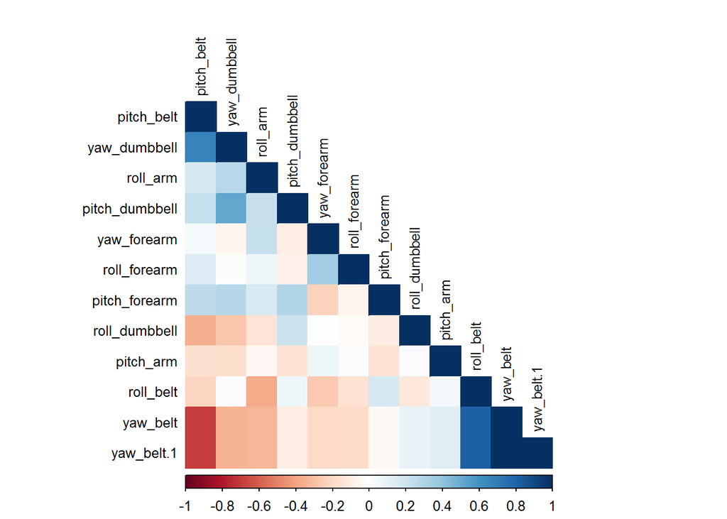

```r
corMatrix <- cor(pmlTrain[,c("roll_belt","roll_arm", "roll_dumbbell", "roll_forearm",
                         "pitch_belt", "pitch_arm", "pitch_dumbbell", "pitch_forearm",
                         "yaw_belt", "yaw_belt", "yaw_dumbbell", "yaw_forearm")])
corrplot(corMatrix, order = "FPC", method = "color", type = "lower",
         tl.cex = 0.8, tl.col = rgb(0, 0, 0))
```

The highly correlated variables are shown in dark colors in the graph above.

## Building the model

We learned the random forest approach in the class, by using k-fold cross-validation to reduce uncertainty on future predictions.

```r
inTrain <- createDataPartition(pmlTrain$classe, p = 0.7, list = FALSE)
training <- pmlTrain[inTrain,]
validation <- pmlTrain[-inTrain,]

#Using all variables
fitControl <- trainControl(method = "repeatedcv",
                           number = 20,
                           repeats = 20)

rfmod2 <- train(classe ~ ., data = training[,c("classe", "roll_belt","roll_arm", "roll_dumbbell", "roll_forearm",
                                              "pitch_belt", "pitch_arm", "pitch_dumbbell", "pitch_forearm",
                                              "yaw_belt", "yaw_arm", "yaw_dumbbell", "yaw_forearm")],
                method = "rf", ntree = 20, trControl = fitControl)
rfmod2
```

```
## Random Forest
##
## 13737 samples
##    12 predictor
##     5 classes: 'A', 'B', 'C', 'D', 'E'
##
## No pre-processing
## Resampling: Cross-Validated (20 fold, repeated 20 times)
## Summary of sample sizes: 13049, 13050, 13050, 13052, 13050, 13048, ...
## Resampling results across tuning parameters:
##
##   mtry  Accuracy   Kappa
##    2    0.9816697  0.9768133
##    7    0.9838066  0.9795189
##   12    0.9773170  0.9713150
##
## Accuracy was used to select the optimal model using  the largest value.
## The final value used for the model was mtry = 7.
```

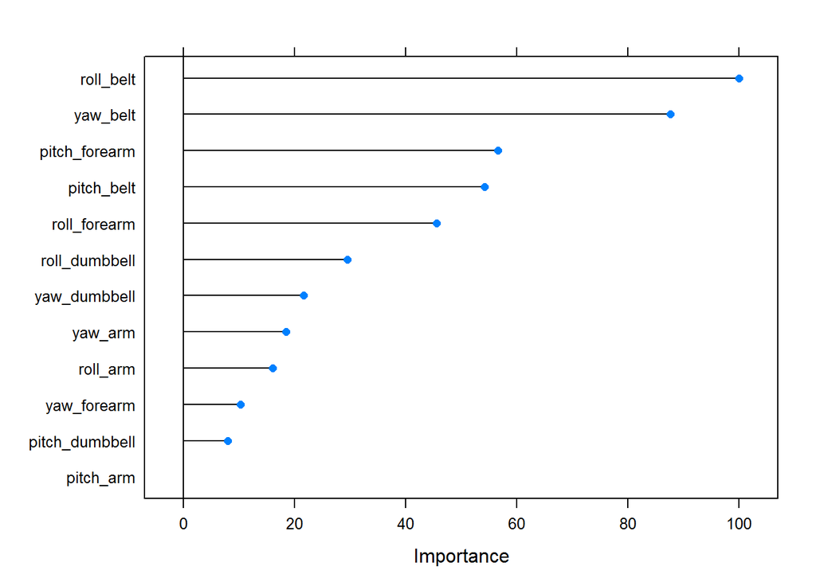

```r
plot(varImp(rfmod2))
```

```r
confusionMatrix(rfmod2, newdata = predict(rfmod2, newdata = validation))
```

```
## Cross-Validated (20 fold, repeated 20 times) Confusion Matrix
##
## (entries are percentual average cell counts across resamples)
##
##           Reference
## Prediction    A    B    C    D    E
##          A 28.2  0.2  0.0  0.0  0.0
##          B  0.1 18.8  0.2  0.0  0.1
##          C  0.0  0.3 17.1  0.1  0.1
##          D  0.0  0.1  0.2 16.2  0.1
##          E  0.0  0.0  0.0  0.0 18.1
##
##  Accuracy (average) : 0.9838
```

```r
predrf<-predict(rfmod2, newdata=validation)
confusionMatrix(predrf, validation$classe)
```

```
## Confusion Matrix and Statistics
##
##           Reference
## Prediction    A    B    C    D    E
##          A 1668    6    1    2    0
##          B    5 1109    7    2    1
##          C    0   16 1011   15    5
##          D    0    5    7  944    4
##          E    1    3    0    1 1072
##
## Overall Statistics
##
##                Accuracy : 0.9862
##                  95% CI : (0.9829, 0.9891)
##     No Information Rate : 0.2845
##     P-Value [Acc > NIR] : < 2e-16
##
##                   Kappa : 0.9826
##  Mcnemar's Test P-Value : 0.03319
##
## Statistics by Class:
##
##                      Class: A Class: B Class: C Class: D Class: E
## Sensitivity            0.9964   0.9737   0.9854   0.9793   0.9908
## Specificity            0.9979   0.9968   0.9926   0.9967   0.9990
## Pos Pred Value         0.9946   0.9867   0.9656   0.9833   0.9954
## Neg Pred Value         0.9986   0.9937   0.9969   0.9959   0.9979
## Prevalence             0.2845   0.1935   0.1743   0.1638   0.1839
## Detection Rate         0.2834   0.1884   0.1718   0.1604   0.1822
## Detection Prevalence   0.2850   0.1910   0.1779   0.1631   0.1830
## Balanced Accuracy      0.9971   0.9853   0.9890   0.9880   0.9949
```

## Expected out of sample error rate

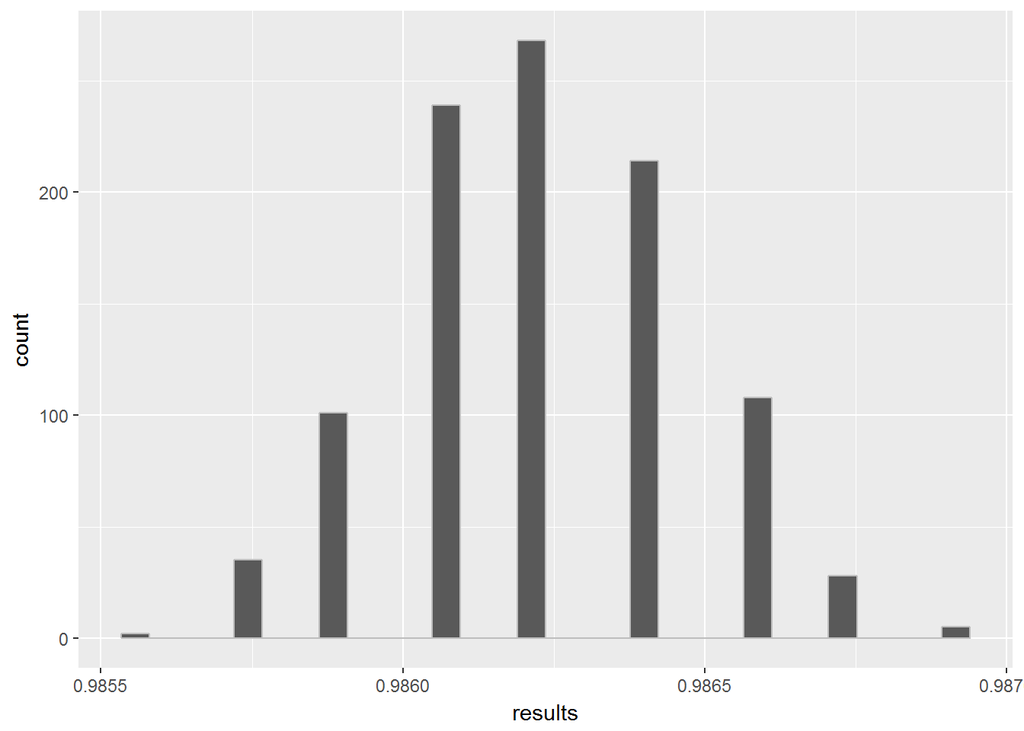

```r
n <- 1000
results <- rep(NA, n)
for (i in 1:n){
  results[i] <- sum(predict(rfmod2, newdata = validation) == validation$classe)/nrow(validation)
}
qplot(results, col = I("gray"))
```

```r
# The average asserted rate
mean(results)
```

```
## [1] 0.9862328
```

```r
# The mean error rate
1 - mean(results)
```

```
## [1] 0.0137672
```

## Applying the selected Model to the Testing data

```r
solutions <- rep(NA, 20)
for(i in 1:20){
  testIdSet <- filter(pmlTest, problem_id == i)
  solutions[i] <- as.vector(predict(rfmod2, newdata = testIdSet))
}
solutions
```

```
##  [1] "B" "A" "B" "A" "A" "E" "D" "B" "A" "A" "B" "C" "B" "A" "E" "E" "A"
## [18] "B" "B" "B"
```